# Search Elevations Experiment

Gordon Lam

01/08/2022

# Recommendation Summary

It is recommended to continue the use of manual elevations for existing queries that have already been manually elevated as opposed to switching to automated elevations. To ensure the customer’s outcomes are achieved, the customer’s engagement rate (i.e total customers exporting/paying for license) was used as the primary measure of success and finds in favor of continuing the use of manual elevations.

Elevations refers to the mechanism of returning search query results to the user. Manual elevations refers to search query results or media is manually mapped and tagged against catalog of searchable terms. Automated elevations refers to use of automated algorithm to return query results to the user.

Import packages and data

```r
library(tidyverse)
library(lubridate)

#Import data
file_dir <- "~/Documents/GitHub/Search Elevation"
setwd(file_dir)
exp_data <- read_csv("manual_elevations_experiment_data.csv")
```

Data Exploration

```r
# Data types
head(exp_data)
```

```
## # A tibble: 6 × 11
##   experiment_day search_id user_id  experiment_group user_tier query media_types
##            <dbl> <chr>     <chr>    <chr>            <chr>     <chr> <chr>
## 1             65 AOGFabmo  51b2325a B                free      spee… RV
## 2             65 AIT27lH-  97c2ab50 A                paid      line  RV
## 3             65 AMgr6dQc  d626988c B                free      butt… RV
## 4             65 WKgECNwN  8bcaf483 B                free      apple RV
## 5             65 dzdr0OMT  ca240171 A                paid      bann… RV
## 6             65 NahXXvv3  672bd410 A                free      stars RV
## # … with 4 more variables: num_elevations <dbl>, num_clicks <dbl>,
## #   num_exported_results <dbl>, num_licenses <dbl>
```

Total count of data for entire period

```r
message(exp_data %>% nrow())
```

```
## 1688377
```

Daily Volumes

```r
daily_volume <- exp_data %>%
    group_by(experiment_day,experiment_group) %>%
    summarise(
      total_click = sum(num_clicks),
      total_exported = sum(num_exported_results),
      total_license = sum(num_licenses)
    ) %>%
    arrange(experiment_day)
```

```
## $title
## [1] "Total clicks daily"
##
## attr(,"class")
## [1] "labels"
```

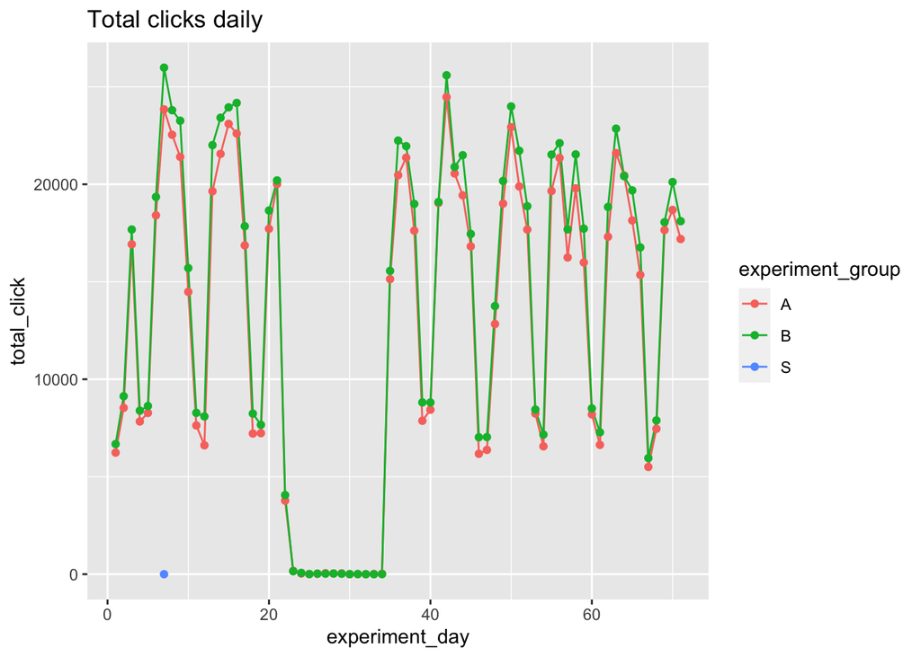

```r
#total clicks
ggplot(data=daily_volume, aes(x=experiment_day, y=total_click, group=experiment_group)) +
  geom_line(aes(colour=experiment_group)) +
  geom_point(aes(colour=experiment_group)) +
  print(ggtitle("Total clicks daily"))
```

```
## $title
## [1] "Total exported daily"
##
## attr(,"class")
## [1] "labels"
```

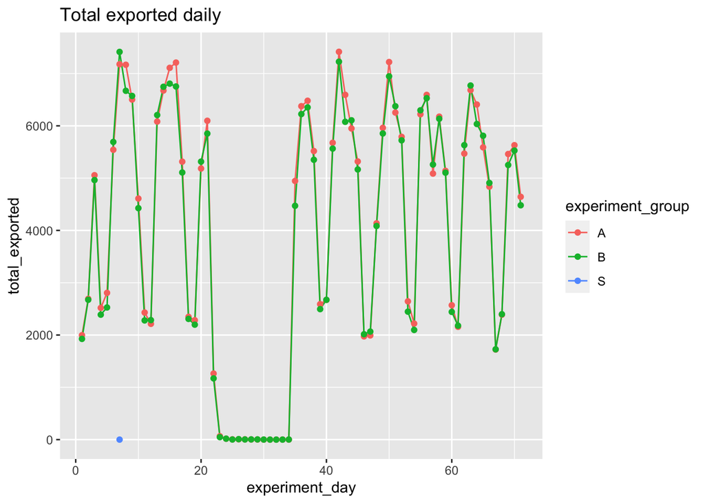

```r
#total exported
ggplot(data=daily_volume, aes(x=experiment_day, y=total_exported, group=experiment_group)) +
  geom_line(aes(colour=experiment_group)) +
  geom_point(aes(colour=experiment_group)) +
  print(ggtitle("Total exported daily"))
```

```
## $title
## [1] "Total license daily"
##
## attr(,"class")
## [1] "labels"
```

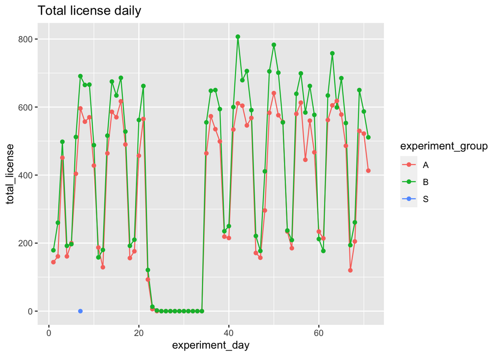

```r
#total license
ggplot(data=daily_volume, aes(x=experiment_day, y=total_license, group=experiment_group)) +
  geom_line(aes(colour=experiment_group)) +
  geom_point(aes(colour=experiment_group)) +
  print(ggtitle("Total license daily"))
```

Snapshot into ‘seasonality’

```r
#Why does it trough?
exp_data %>%
    group_by(experiment_day) %>%
    summarise(
      total_click = sum(num_clicks)
    ) %>%
    #10k-20k is some arbitrary lower and upper bound for the troughs
    filter(total_click >= 10000 & total_click <= 20000)
```

```
## # A tibble: 18 × 2
##    experiment_day total_click
##             <dbl>       <dbl>
##  1              1       12913
##  2              2       17661
##  3              4       16220
##  4              5       16898
##  5             11       15905
##  6             12       14704
##  7             18       15452
##  8             19       14899
##  9             39       16680
## 10             40       17243
## 11             46       13200
## 12             47       13408
## 13             53       16685
## 14             54       13721
## 15             60       16701
## 16             61       13911
## 17             67       11458
## 18             68       15345
```

Findings:  
- every 5 days or so, there is a 2 day trough. Most likely due to weekend, there is lower engagement

# Data Quality checks

## 1) Data drop out

```r
exp_data %>%
    group_by(experiment_day) %>%
    summarise(
      total_click = sum(num_clicks)
    ) %>%
    filter(total_click <= 2500) %>%
    arrange(experiment_day)
```

```
## # A tibble: 12 × 2
##    experiment_day total_click
##             <dbl>       <dbl>
##  1             23         324
##  2             24         105
##  3             25          13
##  4             26          49
##  5             27          76
##  6             28          70
##  7             29          67
##  8             30           8
##  9             31          12
## 10             32           1
## 11             33          12
## 12             34          28
```

Findings:  
- Several days with clear drop outs in data

## 2) Num_elevations should only apply to group by A

Based on data dictionary - these are related to manual elevations

```r
# Store problematic queries
dq_search_2 <- exp_data %>%
  filter(experiment_group == 'B' & num_elevations > 0)
dq_search_2
```

```
## # A tibble: 59 × 11
##    experiment_day search_id user_id experiment_group user_tier query media_types
##             <dbl> <chr>     <chr>   <chr>            <chr>     <chr> <chr>
##  1             22 AJDEc7S4  8fba0d… B                paid      Lines RV
##  2             14 BFj1DnXe  8fba0d… B                paid      Free… RV
##  3             14 ANLgozpW  09e712… B                paid      Free… RV
##  4              9 d9bM8IAX  fd61a6… B                paid      fash… RV
##  5              9 LuvCPdY1  fd61a6… B                paid      fash… RV
##  6             22 Q-z4UdKw  8fba0d… B                paid      Shap… RV
##  7             22 VhM0q60p  8fba0d… B                paid      Shap… RV
##  8             14 APYyhFa6  8fba0d… B                paid      Fram… RV
##  9             14 W-9kbMCy  8fba0d… B                paid      Fram… RV
## 10             14 eUSV-i3t  8fba0d… B                paid      Shap… RV
## # … with 49 more rows, and 4 more variables: num_elevations <dbl>,
## #   num_clicks <dbl>, num_exported_results <dbl>, num_licenses <dbl>
```

Findings:  
- Group B has 59 rows that have manual elevation when it should be entirely automated

## 3) Duplication checks

Data duplication checks - each search id must be unique

```r
# Data duplication
# Store problematic queries
dq_search_3 <- exp_data %>%
  group_by(search_id) %>%
  filter(n() >= 2)
dq_search_3
```

```
## # A tibble: 4 × 11
## # Groups:   search_id [2]
##   experiment_day search_id user_id  experiment_group user_tier query media_types
##            <dbl> <chr>     <chr>    <chr>            <chr>     <chr> <chr>
## 1             71 AJUy1gyk  2c79fb2b A                paid      bord… RV
## 2              7 APZmuEnR  1b2c2c01 A                free      birt… RV
## 3             53 APZmuEnR  4556af3c A                paid      flow… RV
## 4             34 AJUy1gyk  26c8f45c B                free      bord… RV
## # … with 4 more variables: num_elevations <dbl>, num_clicks <dbl>,
## #   num_exported_results <dbl>, num_licenses <dbl>
```

Findings:  
- 2 duplicated search IDs for clearly different records from 4 different users

## 4) Null checks

Null fields - fields with missing data

```r
#Find columns that have NA's in them
#1) For each column in the df, convert to logical then sum values == true
null_vectors <- colSums(is.na(exp_data) > 0)
colnames(exp_data)[null_vectors > 0]
```

```
## [1] "query"
```

```r
# Store problematic records
dq_search_4 <-
exp_data %>%
  filter(is.na(query))
dq_search_4
```

```
## # A tibble: 2 × 11
##   experiment_day search_id user_id  experiment_group user_tier query media_types
##            <dbl> <chr>     <chr>    <chr>            <chr>     <chr> <chr>
## 1             13 MMMJsx5d  4e1858ec B                paid      <NA>  V
## 2              6 AIqkk5v1  12355455 A                paid      <NA>  V
## # … with 4 more variables: num_elevations <dbl>, num_clicks <dbl>,
## #   num_exported_results <dbl>, num_licenses <dbl>
```

Findings:  
- 2 rows that have null values from the search query

## 5) Column checks for validity

```r
#experiment groups
exp_data %>%
  group_by(experiment_group) %>%
  summarise(count = n())
```

```
## # A tibble: 3 × 2
##   experiment_group  count
##   <chr>             <int>
## 1 A                840702
## 2 B                847674
## 3 S                     1
```

```r
#user tier
exp_data %>%
  group_by(user_tier) %>%
  summarise(count = n())
```

```
## # A tibble: 2 × 2
##   user_tier   count
##   <chr>       <int>
## 1 free      1179952
## 2 paid       508425
```

```r
#media types
exp_data %>%
  group_by(media_types) %>%
  summarise(count = n())
```

```
## # A tibble: 3 × 2
##   media_types   count
##   <chr>         <int>
## 1 R              6759
## 2 RV          1675970
## 3 V              5648
```

```r
#query
exp_data %>%
  group_by(query) %>%
  summarise(count = n())
```

```
## # A tibble: 336 × 2
##    query           count
##    <chr>           <int>
##  1 20% text          217
##  2 4th of july      3607
##  3 Abstract           15
##  4 adventures         13
##  5 alphabet frame     19
##  6 alphabet frames    14
##  7 america          5800
##  8 american flag    8745
##  9 animal icon        35
## 10 animal icons        8
## # … with 326 more rows
```

```r
# Store problematic records
dq_search_5 <-
exp_data %>%
  filter(experiment_group == 'S')
dq_search_5
```

```
## # A tibble: 1 × 11
##   experiment_day search_id user_id  experiment_group user_tier query media_types
##            <dbl> <chr>     <chr>    <chr>            <chr>     <chr> <chr>
## 1              7 M4kyRzfi  09d54485 S                paid      chri… RV
## # … with 4 more variables: num_elevations <dbl>, num_clicks <dbl>,
## #   num_exported_results <dbl>, num_licenses <dbl>
```

Findings:  
- Experiment_group has erroneous group ‘S’  
- 336 unique queries with some, completely unreadable e.g. “brand:BABCTFGu9Rg^100 tropical”

## 6) Experimental setup check

JOIN queries_with_elevations qe  
ON s.query = qe.query  
AND s.media_types = qe.media_types  
AND s.user_tier = qe.user_tier  
CROSS JOIN min_search_date msd

The impact of this join is that, only queries (of a particular media_type and user_tier) from experiment A are fully included. This means that all experiment A are queries that have manual elevations. Experiment B however may have queries that are left out.

Check experiment design - is the experiment group set up properly?

```r
#Check number of
exp_data %>%
  group_by(experiment_group) %>%
  summarise(dist_group = n_distinct(query,media_types,user_tier))
```

```
## # A tibble: 3 × 2
##   experiment_group dist_group
##   <chr>                 <int>
## 1 A                       579
## 2 B                       556
## 3 S                         1
```

```r
# check how many distinct groups each query has
query_dist <- exp_data %>%
  group_by(query,media_types,user_tier) %>%
  summarise(dist_exp_groups = n_distinct(experiment_group)) %>%
  filter(dist_exp_groups != 2)
query_dist
```

```
## # A tibble: 32 × 4
## # Groups:   query, media_types [29]
##    query                          media_types user_tier dist_exp_groups
##    <chr>                          <chr>       <chr>               <int>
##  1 Abstract                       V           paid                    1
##  2 Animals                        V           paid                    1
##  3 brand:BABCTFGu9Rg^100 tropical V           free                    1
##  4 Chart                          RV          free                    1
##  5 Charts                         RV          free                    1
##  6 christmas                      RV          paid                    3
##  7 Christmas Tree                 RV          paid                    1
##  8 Food Icon                      RV          paid                    1
##  9 free photo                     RV          paid                    1
## 10 Free photo                     RV          free                    1
## # … with 22 more rows
```

```r
#Exclude 'christmas' as it has more than 2 group and store problematic queries
dq_search_6 <- exp_data %>%
  inner_join(query_dist, by = c("query","media_types","user_tier")) %>%
  select(-dist_exp_groups) %>%
  filter(query != "christmas") %>%
  arrange(experiment_group)
dq_search_6
```

```
## # A tibble: 49 × 11
##    experiment_day search_id user_id experiment_group user_tier query media_types
##             <dbl> <chr>     <chr>   <chr>            <chr>     <chr> <chr>
##  1             37 QdrbpjnH  0bb3b0… A                free      Scho… RV
##  2             30 IQLeazZy  31643d… A                free      Grad… RV
##  3             30 AKsQXnJ2  31643d… A                free      Grad… RV
##  4             28 AKXKk8EU  a70c47… A                paid      vint… RV
##  5             52 AKka6lBP  b58f33… A                free      hosp… RV
##  6             16 AKRLCyvs  35408a… A                paid      Icons RV
##  7             21 AN-VtZvf  1fdb6c… A                paid      Icons RV
##  8             44 BfWIkXLH  c63c38… A                paid      vale… RV
##  9             53 ALshMupD  1b0b60… A                free      Chart RV
## 10             62 AO7NbiZQ  169661… A                free      Chart RV
## # … with 39 more rows, and 4 more variables: num_elevations <dbl>,
## #   num_clicks <dbl>, num_exported_results <dbl>, num_licenses <dbl>
```

Finding:  
- Based on the script, only distinct queries by media_types by user tiers, from experiment A with > 0 no. elevations are counted. This means only records from that match the join condition from A should appear. Potentially this can impact experiment group B as the users from group B may not make the same search query in the period (potentially fewer records assessed)  
- There are 23 more distinct groups in A than there are in B  
- Interestingly, there are groups that only exist in B not found in A - Likely due to some items in group B classified as group A (related to above issue)

## 7) Exports before clicks

Is it possible to export/pay for license without click?

```r
# Check if it is possible to have exports/pay for license prior to click
exp_data %>%
  filter(num_clicks == 0 & num_exported_results + num_licenses >= 1) %>%
  nrow()
```

```
## [1] 0
```

```r
exp_data %>%
  filter(num_exported_results == 0 & num_licenses >= 1) %>%
  nrow()
```

```
## [1] 137
```

Therefore assume that the exports/pay for license must be made with records into click

#### Insights…

- Seasonality in Data - decrease in data volumes appear to be every 5 days for roughly a 2-day period. This could indicate decrease in searches generally on the weekend.
- Data quality issues…
  1. Experiment_group - erroneous ‘S’ type -> Remove ‘S’ type for experiment
  2. Limited data recorded for experiment_day between 23-34 -> Check volume of data
  3. Group B has 59 rows with > 0 manual elevations (should be 0?) -> Remove
  4. Duplication on 2 search_ids -> Either remove or re-assign new id
  5. NA shows that 2 records are returned for empty query -> Remove
  6. Unfair distribution of records in experiment group A -> Only keep distinct query, media types, user tiers that intersect

# Data Cleaning

Aggregate rows to remove then do a set difference to keep only values in A that are common.

```r
discard_search_ids <- dq_search_2 %>%
  union(dq_search_3) %>%
  union(dq_search_4) %>%
  union(dq_search_5) %>%
  union(dq_search_6)

#Consider after day 34
clean_data <- exp_data %>%
  filter(experiment_day > 34) %>%
  setdiff(discard_search_ids)
  #anti_join(discard_search_ids,by = c("search_id"))

#Impact of data removal
message(sprintf('%s%%',round(
                      nrow(discard_search_ids)*100/
                      nrow(exp_data %>%
                        filter(experiment_group != 'S', experiment_day > 34)
                      ),digits = 2)
                )
        )
```

```
## 0.01%
```

We consider after day 34 because…  
1) Stitching up dates will affect the analysis of ‘impact’ of manual elevation  
2) Sufficient data for experimentation post day 34

# 1) Intial exploration of data

Specific measures (over period of cleaned data from group A):  
1) Engagement volume trend - to monitor performance on day-to-day  
2) Average number of clicks - To see how long it takes a customer to find what they want  
3) % of customers who engaged (export/licence) as proportion of customers who clicked  
4) Query level breakdown of above metric - since there are only a few hundred - would be interesting to see top and bottom elevations and work out why the bottom elevations aren’t doing well  
5) Conversion funnel - customers are clicking and also exporting/purchasing license for images

Metrics to build for ‘overall’ impact of manual elevation

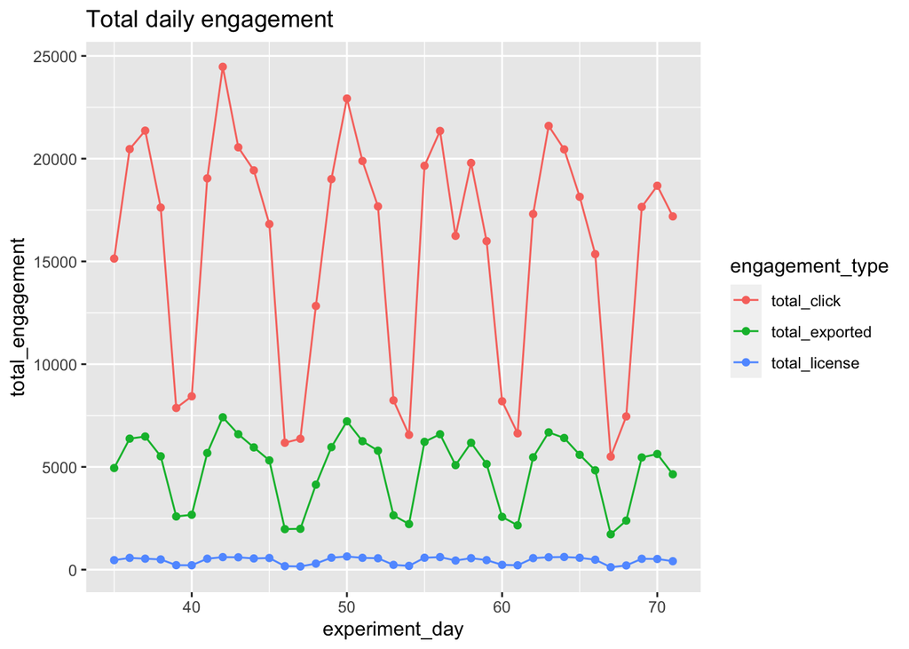

```r
#Daily volumes line chart
daily_volume <- manual_elevations_data %>%
    group_by(experiment_day) %>%
    summarise(
      total_click = sum(num_clicks),
      total_exported = sum(num_exported_results),
      total_license = sum(num_licenses)
    ) %>%
    pivot_longer(col = 2:4, names_to = "engagement_type", values_to = "total_engagement") %>%
    arrange(experiment_day)

ggplot(data=daily_volume, aes(x=experiment_day, y=total_engagement, group_by = engagement_type)) +
  geom_line(aes(colour=engagement_type)) +
  geom_point(aes(colour=engagement_type)) +
  ggtitle("Total daily engagement")
```

```r
#Average number of clicks - remove 0's as the search
message(sprintf('Average number of clicks: %s',round(manual_elevations_data %>%
  summarise(avg_click = mean(num_clicks)),2)
))
```

```
## Average number of clicks: 1.34
```

```r
message(sprintf('Average number of clicks (click > 0): %s',round(manual_elevations_data %>%
  filter(num_clicks > 0) %>%
  summarise(avg_click = mean(num_clicks)),2)
))
```

```
## Average number of clicks (click > 0): 1.99
```

```r
#Export to click ratio
message(sprintf('Export to click ratio: %s',
        round(
          nrow(manual_elevations_data %>%
            filter(num_exported_results > 0)) /
          nrow(manual_elevations_data %>%
            filter(num_clicks > 0))
        ,2)
))
```

```
## Export to click ratio: 0.52
```

```r
#License to click ratio
message(sprintf('License to click ratio: %s',
        round(
          nrow(manual_elevations_data %>%
            filter(num_licenses > 0)) /
          nrow(manual_elevations_data %>%
            filter(num_clicks > 0))
        ,2)
))
```

```
## License to click ratio: 0.04
```

```r
#Search bounce rate - users who have made a search query but have not made any clicks
#Logic: num of searches == 0 / total searches
message(sprintf('Search bounce rate: %s',
round(nrow(manual_elevations_data %>% filter(num_clicks == 0))/
nrow(manual_elevations_data), digits = 2)))
```

```
## Search bounce rate: 0.33
```

```r
#Search query performance - acted means the customer has exported/purchased license
search_data <- manual_elevations_data %>%
  mutate(acted = ifelse(num_exported_results + num_licenses > 0,1,0)) %>%
  group_by(query) %>%
  summarise(
    total_acted = sum(acted),
    total_query = n(),
    engagement_rate = round(sum(acted)/n(),2)
  ) %>%
  arrange(desc(engagement_rate),total_query)
head(search_data,10)
```

```
## # A tibble: 10 × 4
##    query              total_acted total_query engagement_rate
##    <chr>                    <dbl>       <int>           <dbl>
##  1 Christmas Tree               1           1            1
##  2 Food Icon                    1           1            1
##  3 Tombstone                    1           1            1
##  4 Social media icons           3           3            1
##  5 education icons              2           3            0.67
##  6 Instagram                  418         642            0.65
##  7 instagram                11708       18173            0.64
##  8 Question Mark               22          36            0.61
##  9 tick                      1019        1679            0.61
## 10 Valentines                   3           5            0.6
```

```r
tail(search_data,10)
```

```
## # A tibble: 10 × 4
##    query          total_acted total_query engagement_rate
##    <chr>                <dbl>       <int>           <dbl>
##  1 phonebooth               0           3               0
##  2 cobweb                   0           5               0
##  3 House                    0           5               0
##  4 web wireframes           0           5               0
##  5 music icons              0           6               0
##  6 mockups                  0           9               0
##  7 Photos                   0          10               0
##  8 Photo                    0          16               0
##  9 charts                   0          18               0
## 10 Gaming                   0          27               0
```

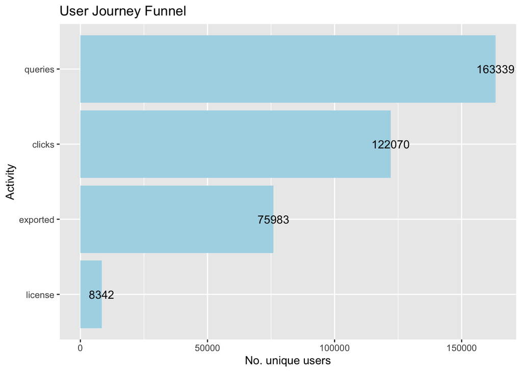

```r
#Conversion funnel
df <- manual_elevations_data %>%
  summarise(
    queries = n_distinct(user_id),
    clicks = n_distinct(user_id[num_clicks > 0]),
    exported = n_distinct(user_id[num_exported_results > 0]),
    license  = n_distinct(user_id[num_licenses > 0]),
  ) %>%
  pivot_longer(1:4, names_to = "no_", values_to = "num_cust") %>%
  mutate(id = row_number()) %>%
  arrange(desc(num_cust))

ggplot(data=df, aes(x = reorder(no_,id,decreasing = TRUE), y=num_cust)) +
  geom_bar(stat="identity", fill = "light blue") +
  geom_text(aes(label = signif(num_cust)), nudge_y = 0) +
  coord_flip() +
  ylab("No. unique users") +
  xlab("Activity") +
  ggtitle("User Journey Funnel")
```

# 2) Experimentation approach

### Define outcome of experiment - What is the goal of the experimentation?

To improve customer engagement and conversions to exports and sales, a new automated elevation mechanism has been developed for the search function. The experiment will help us determine whether the new method for elevation is provides more relevant content to our customers on the web platform.

Commentary: We could also include a financial outcome which would be more pragmatic, though the data somewhat better serves for an outcome that is customer/engagement centric.

### Define hypothesis and behaviors - How do we expect customers to behave:

#### Hypothesis:

We believe that having a reliable search function that provides relevant and curated content to a user’s search query will impact their decision to choose, use and/or pay for content (images) from the web platform.

By implementing automated elevations, we will be able to provide elevations across a broader range of queries in a timely manner and therefore ensure that content for users are useful and relevant

We know this is true if we see a significant uplift in user engagement rates and fall in the search bounce rate

- Preferred:
  1. Customers are making more exports and number of licenses with content from their search query results
  2. Customers who make a search can find their content relatively quickly (few search results)
- Least preferred:
  1. Customers are making queries but does not end up clicking, exporting or purchasing a license
  2. Customers making more searches

### Key Success metrics - How we will measure customer behaviour and determine if outcome is met

We know that our hypothesis is true when:  
1) Click-through volumes (since engagement volumes may be higher for more relevant content)  
2) Proportion of customers converted to export/licensing over total clicks

### Statistical inferences

- Implement proportion significance testing to compare volumes of observed data to understand whether the differences are material or if due to possible fluctuations in the between experiment group

  How:
  1. H0: There is no difference between between the two populations
  2. HA: There is a difference (two sided)

What can we do with this analysis?  
Proportion testing will help us understand whether a metric is considered significant or not, e.g. is 6% vs 7% considered important? Understanding which measures are significant will affect the conclusions we can draw about the two experiment groups and therefore the final recommendation.

# Completed analysis

Priority of metrics  
1) Proportion of customers converted to export/licensing over total clicks - Since conversion is an important driver of how relevant images are to customers  
2) Click-through volumes (since engagement volumes may be higher for more relevant content) - Click through can be noisy - since customers may click on things that may not be relevant to them

```r
metric_data <- clean_data %>%
  group_by(experiment_group) %>%
  summarise(
    #counts
    records = n(),
    cust_total = n_distinct(user_id), #Total number of customers
    cust_clicks = n_distinct(user_id[num_clicks > 0]), #Total customers that have clicked
    cust_export = n_distinct(user_id[num_exported_results> 0]), #Total customers that have exported
    cust_license = n_distinct(user_id[num_licenses> 0]), #Total customers that have paid for a design
    cust_engaged = n_distinct(user_id[num_exported_results + num_licenses > 0]), #Total number of customers that have exported/paid for design
    #metrics - user level
    click_rate = round(cust_clicks/cust_total,4),
    export_rate = round(cust_export/cust_clicks,4),
    license_rate = round(cust_license/cust_clicks,4),
    eng_rate = round(cust_engaged/cust_clicks,4),
    avg_clicks = round(sum(num_clicks)/cust_total,2),
    avg_exports = round(sum(num_exported_results)/cust_total,2),
    avg_license = round(sum(num_licenses)/cust_total,2)
  )

metric_data %>%
  select(experiment_group,click_rate,export_rate,license_rate,eng_rate,avg_clicks, avg_exports, avg_license)
```

```
## # A tibble: 2 × 8
##   experiment_group click_rate export_rate license_rate eng_rate avg_clicks
##   <chr>                 <dbl>       <dbl>        <dbl>    <dbl>      <dbl>
## 1 A                     0.747       0.622       0.0683    0.622       3.54
## 2 B                     0.785       0.606       0.0783    0.606       3.77
## # … with 2 more variables: avg_exports <dbl>, avg_license <dbl>
```

```r
#Sig. test
alpha = 0.05 #significance
confidence = 1-alpha

message(colnames(metric_data)[8])
```

```
## click_rate
```

```r
print(prop.test(x=  metric_data %>% pull(cust_clicks), n = metric_data %>% pull(cust_total),
          conf.level=confidence))
```

```
##
##  2-sample test for equality of proportions with continuity correction
##
## data:  metric_data %>% pull(cust_clicks) out of metric_data %>% pull(cust_total)
## X-squared = 658.62, df = 1, p-value < 2.2e-16
## alternative hypothesis: two.sided
## 95 percent confidence interval:
##  -0.04094652 -0.03513142
## sample estimates:
##    prop 1    prop 2
## 0.7473414 0.7853804
```

```r
message(colnames(metric_data)[9])
```

```
## export_rate
```

```r
print(prop.test(x=  metric_data %>% pull(cust_export), n = metric_data %>% pull(cust_clicks),
          conf.level=confidence))
```

```
##
##  2-sample test for equality of proportions with continuity correction
##
## data:  metric_data %>% pull(cust_export) out of metric_data %>% pull(cust_clicks)
## X-squared = 72.951, df = 1, p-value < 2.2e-16
## alternative hypothesis: two.sided
## 95 percent confidence interval:
##  0.01282267 0.02047292
## sample estimates:
##    prop 1    prop 2
## 0.6224543 0.6058065
```

```r
message(colnames(metric_data)[10])
```

```
## license_rate
```

```r
print(prop.test(x=  metric_data %>% pull(cust_license), n = metric_data %>% pull(cust_clicks),
          conf.level=confidence))
```

```
##
##  2-sample test for equality of proportions with continuity correction
##
## data:  metric_data %>% pull(cust_license) out of metric_data %>% pull(cust_clicks)
## X-squared = 90.094, df = 1, p-value < 2.2e-16
## alternative hypothesis: two.sided
## 95 percent confidence interval:
##  -0.011964494 -0.007864021
## sample estimates:
##     prop 1     prop 2
## 0.06833784 0.07825210
```

```r
message(colnames(metric_data)[11])
```

```
## eng_rate
```

```r
print(prop.test(x=  metric_data %>% pull(cust_engaged), n = metric_data %>% pull(cust_clicks),
          conf.level=confidence))
```

```
##
##  2-sample test for equality of proportions with continuity correction
##
## data:  metric_data %>% pull(cust_engaged) out of metric_data %>% pull(cust_clicks)
## X-squared = 72.989, df = 1, p-value < 2.2e-16
## alternative hypothesis: two.sided
## 95 percent confidence interval:
##  0.01282653 0.02047648
## sample estimates:
##    prop 1    prop 2
## 0.6225362 0.6058847
```

Note: we calculate the above metrics at a customer level as it is easier to determine proportions.

Insights:  
- Based on the click-through rate, Customers in group B is clicking more than group A and this is supported by the avg number of clicks per user 3.77 > 3.54. Despite this, the overall engagement of the customer in group B is lower, mainly due to customers not converting as much (engagement refers to paying for license or exports). This suggest that elevated content is interesting but may not be as relevant to the customer’s need.  
- When we look at licensing individually, we see that customers are more likely pay for the license.  
- We assume the ratio of paying to free users are the same across groups - though we can check easily

# 3) Final recommendation

It is recommended to keep manual elevations (for the distinct query, user_tier, media_type) as the engagement rate (which refers to the number of customers exporting and/or paying for a license as a proportion of total customers that have clicked) is higher for group A as to group B.

It is important to note that this recommendation is made explicitly maximize customer conversions as opposed to a more pragmatic approach which may also consider trade-offs and deficiencies of maintaining a manual elevation workflow.